# Many Analysts

# What effect does statistics anxiety have on attainment?

## Effect Size Summary

d = -0.28, 95% CI [-0.42, -0.13] based on N = 716.

## Summary of Analysis Approach

We analysed data from UK Psychology undergraduates with university-reported statistics module grades who passed relevant attention checks. Statistics anxiety was measured using the total score of the 23 Statistics Anxiety Rating Scale (STARS) questions. Our main analysis examined the relationship between total STARS score and statistics module grade (%), explored using Pearson’s correlation coefficient, converted to Cohen’s d. To investigate the reliability of this result, additional explorations included the correlation between maths and statistics anxiety so we could confirm that the use of “maths” vs “statistics” in the survey questions did not bias results. Additionally, a linear regression attempting to control for university, gender, and degree year was included. These final analyses were exploratory and do not aim to establish causation, instead ensuring that our final result still seemed reasonable when accounting for these other factors.

## Details of the Analysis

### Description of Dataset

The data is from an International Multi-Centre Study of Statistics and Mathematics Anxieties and Related Variables in University Students (the SMARVUS Dataset) (Terry et al. 2023). This dataset contains survey responses from 12,570 students from 100 universities in 35 countries. They attempted to measure anxieties (statistics and mathematics), collected demographics, previous mathematics grades, self-reported and official statistics grades, and statistics module details.

### Data Processing

```r
smarvus_raw <- read_csv("smarvus_complete_050524.csv", show_col_types = FALSE)
```

We chose to include only universities in the UK in our analysis because it is the country with the most observations, at 2962, making up almost 24% of the data. Additionally, this ensures that our results are less likely to be affected by any other cultural or language-based differences between participants that could affect grades or statistics anxiety. Finally, all UK universities reported their grades on a percentage scale, preventing possible issues arising from different grading scales.

```r
smarvus_uk <- smarvus_raw[smarvus_raw$country %in% c("England", "Scotland", "Northern Ireland"), ]
```

Six “attention checks” were built in to the survey. We used the first 3 of these to filter out any participants who weren’t paying attention to questions about their statistics anxiety levels (9.18%), as this would invalidate their other responses.These attention checks were chosen as they come at the end of each section of data that was used, we did not want to exclude useable data based on checks that came after data that we did not need since people may lose attention towards the end of the survey but this does not make their early responses unreliable. Additionally, we filtered out students who responded “No” to the question “Please indicate whether you feel you have answered the previous questions carefully and truthfully” (0.91%), as well as students that responded “Yes” to the question “You have just answered three reasoning problems. Did you look any of the answers up online?” (1.76%). This was to preserve the reliability of responses.

```r
smarvus_filtered <- smarvus_uk %>%
  filter(
    attention_amnesty == "Yes",
    Q7.1_24 == 1,
    Q8.1_21 == 5,
    Q9.1_22 == 1,
    crt_check2 == "No"
  )

# table to check percentage of responders removed after filtering by attention
pct_fail_att <- smarvus_uk %>%
  summarise(
    n = n(),
    pct_fail_amnesty = sum(attention_amnesty != "Yes", na.rm = TRUE) / n * 100,
    pct_fail_check1 = sum(Q7.1_24 != 1, na.rm = TRUE) / n * 100,
    pct_fail_check2 = sum(Q8.1_21 != 5, na.rm = TRUE) / n * 100,
    pct_fail_crt_check2 = sum(crt_check2 != "No", na.rm = TRUE) / n * 100
  )
```

Additionally, we filtered our data to only include Psychology undergraduate students, as they made up the vast majority of degree majors at the UK universities surveyed (94.5%), and this would also improve the strength of our comparisons between students, as different course demands and difficulty levels would also affect anxiety levels.

```r
smarvus_filtered <- smarvus_filtered %>%
  filter(
    eligibility_ug == "Yes",
    eligibility_stats == "Yes",
    degree_major == "Psychology"
  )

# table to check percentage of responders in each degree major
pct_psych <- smarvus_filtered %>%
  count(degree_major) %>%
  mutate(
    pct = n / sum(n) * 100
  )
```

Only 20 universities in the SMARVUS data provided grade information for the statistics course participants were taking at the time of the survey, and of these, 8 were UK universities. We chose to only use university-reported grades instead of student-reported grades, for reliability. To investigate the effect of statistics anxiety on attainment, we removed all missingness from the UK grades data, leading to 795 grade observations.

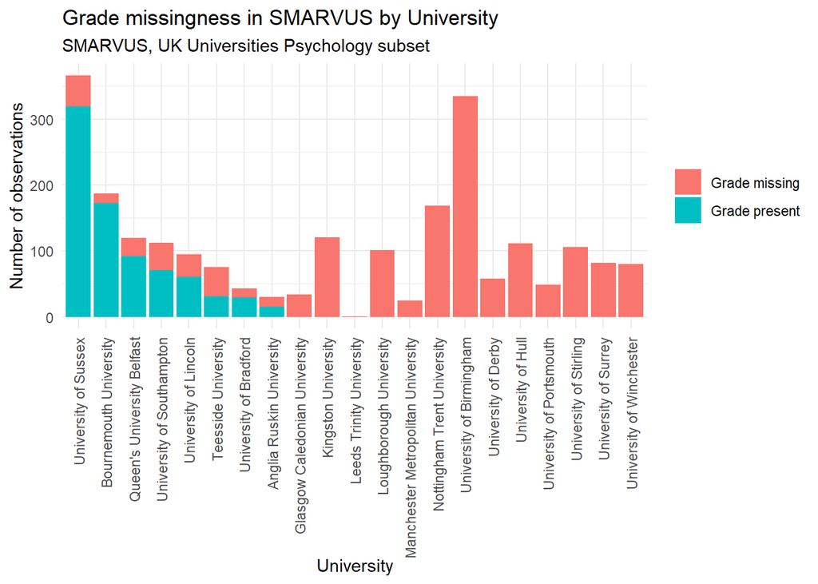

```r
# convert all percentage grades to numeric
# uk grade entries are all percentages or numeric, no letters
smarvus_uk_clean <- smarvus_filtered %>%
  mutate(grade_numeric = parse_number(grade, na = c("", "NA", "Not Available")))

# table of grade data by uk uni
uk_university_nas <- smarvus_uk_clean %>%
  group_by(university) %>%
  summarise(
    n = n(),
    n_na = sum(is.na(grade_numeric)),
    n_not_na = sum(!is.na(grade_numeric))
  )

# convert to long for plotting
uk_nas_long <- uk_university_nas %>%
  pivot_longer(
    cols = c(n_not_na, n_na),
    names_to = "grade_status",
    values_to = "count"
  ) %>%
  mutate(grade_status = recode(grade_status,
                               n_not_na = "Grade present",
                               n_na = "Grade missing"))

# barplot
grade_na_byuni <- ggplot(
  uk_nas_long,
  aes(
    x = fct_reorder(
      university,
      count * (grade_status == "Grade present"),
      .fun = sum,
      .desc = TRUE),
    y = count,
    fill = grade_status)
  ) +
  geom_col() +
  labs(
    title = "Grade missingness in SMARVUS by University",
    subtitle = "SMARVUS, UK Universities Psychology subset",
    x = "University",
    y = "Number of observations",
    fill = NULL
  ) +
  theme_minimal() +
  scale_x_discrete(guide = guide_axis(angle = 90))

grade_na_byuni
```

The degree of missingness also varied largely across degree years, with the majority of observations being in first and second year and over half the grades for these observations being missing. The grade data from the few observations from third and fourth year students were almost completely missing. This could be because the only mandatory statistics courses take place in the 1st and 2nd years of students degrees and so only a few respondents have statistics module grades to report in 3rd and 4th year.

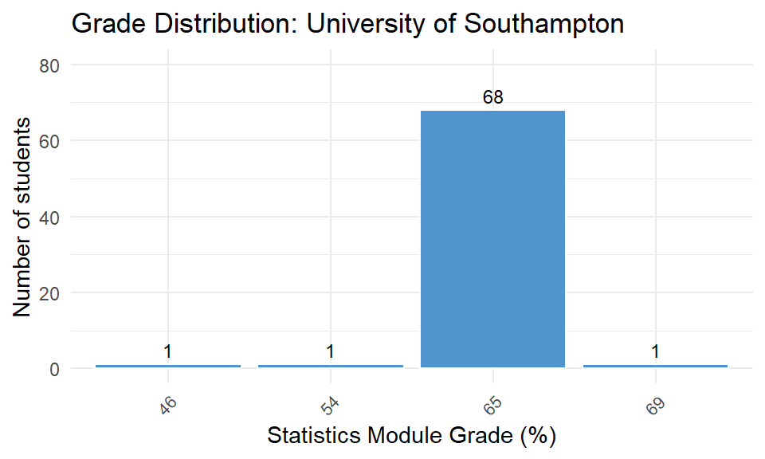

```r
# select reported grades from University of Southampton
grades_southampton <- smarvus_uk_clean[
  !is.na(smarvus_uk_clean$grade_numeric) &
    smarvus_uk_clean$university == "University of Southampton",
]

southampton_plot <- ggplot(
  grades_southampton,
  aes(x = factor(grade_numeric))
) +
  geom_bar(
    fill = "steelblue3",
    colour = "white"
  ) +
  geom_text(
    stat = "count",
    aes(label = after_stat(count)),
    vjust = -0.5,
    size = 3
  ) +
  ylim(0, 80) +
  labs(
    title = "Grade Distribution: University of Southampton",
    x = "Statistics Module Grade (%)",
    y = "Number of students"
  ) +
  theme_minimal() +
  theme(
    axis.text.x = element_text(angle = 45, hjust = 1, size = 8)
  )

southampton_plot
```

As we can see, almost all grades at Southampton were reported as 65%. Of the 71 participants from Southampton that were still included after our initial data preparation, 68 (95.8%) of them had an officially reported grade of 65. We additionally checked that it wasn’t our data cleaning that had led to this issue, but found the same problem when including *all* University of Southampton participants with officially reported grades. This led us to conclude that the grade data from Southampton was unreliable, and perhaps 65 was some kind of placeholder value rather than truly achieved results. As grade data is key to our analysis, we therefore chose to exclude the University of Southampton from our analysis.

```r
# removing all observations that are missing grade data (assuming missing at random),
# also remove zero grades, and University of Southampton
smarvus_uk_cleangrades <- smarvus_uk_clean[
  !is.na(smarvus_uk_clean$grade_numeric) &
    smarvus_uk_clean$grade_numeric != 0 &
    smarvus_uk_clean$university != "University of Southampton", ]

N <- nrow(smarvus_uk_cleangrades)
mean_grade <- mean(smarvus_uk_cleangrades$grade_numeric)
```

Below we see the distribution of the grades from our final cleaned dataset, and see that the majority lie around 65%. Specifically, the mean grade was 66.02%.

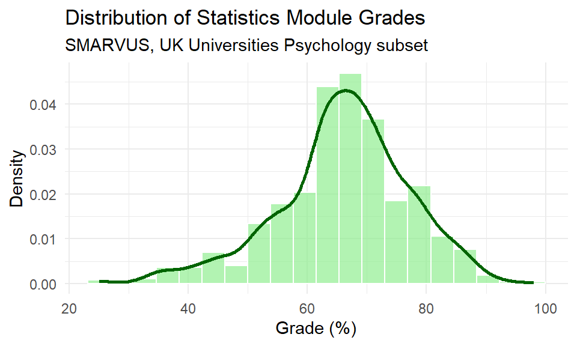

```r
# plotting grade distribution

grades_hist <- ggplot(smarvus_uk_cleangrades, aes(x = grade_numeric)) +
  geom_histogram(
    aes(y = after_stat(density)),
    bins = 20,
    fill = "lightgreen",
    color = "white",
    alpha = 0.7
  ) +
  geom_density(color = "darkgreen", linewidth = 1) +
  labs(
    title = "Distribution of Statistics Module Grades",
    subtitle = "SMARVUS, UK Universities Psychology subset",
    x = "Grade (%)",
    y = "Density"
  ) +
  theme_minimal()

grades_hist
```

### Statistics Anxiety

To measure statistics anxiety, the STARS (Statistics Anxiety Rating Scale) tool was used. The 3 anxiety subscales of STARS were used, giving 23 total items. Each is to be rated on a 5-point scale, with a 1 indicating “no anxiety” related to the stated item, and a 5 indicating “a great deal of anxiety”. We calculated a total STARS score for each participant by summing their responses for the 23 items (excluding the attention check question at the end of the section). The possible range for total STARS score is 23-115, with a higher score indicating greater statistics anxiety.

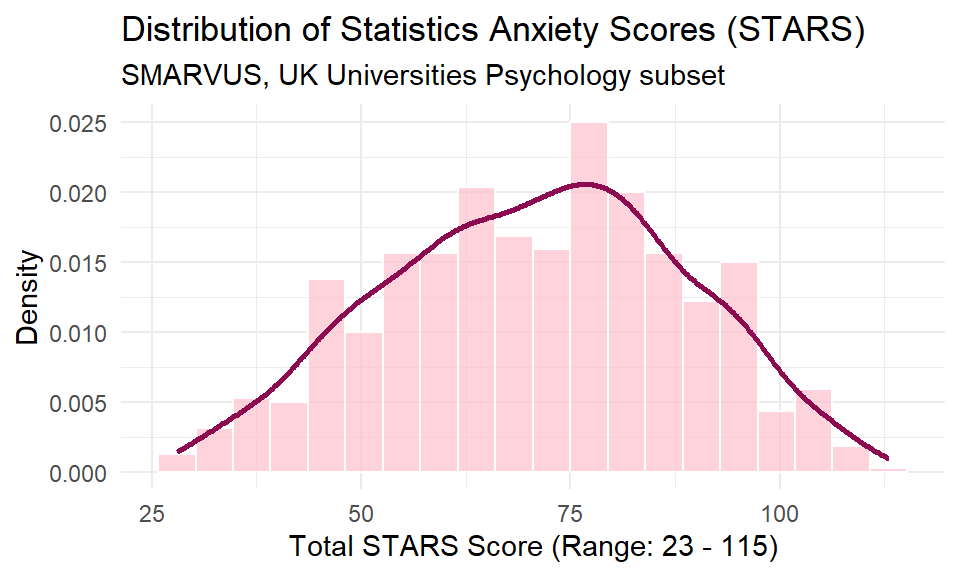

```r
# find stars score for each observation
stars_totals <- smarvus_uk_cleangrades %>%
  subset(select = -c(Q7.1_24)) %>%
  pivot_longer(
    cols = starts_with("Q7.1_"),
    values_to = "STARS"
  ) %>%
  summarise(
    .by = unique_id,
    stars_score = sum(STARS)
  )

# left_join with grade data
smarvus_uk_scored <- smarvus_uk_cleangrades %>%
  left_join(stars_totals, by = "unique_id")

stars_hist <- ggplot(smarvus_uk_scored, aes(x = stars_score)) +
  geom_histogram(
    aes(y = after_stat(density)),
    bins = 20,
    fill = "pink",
    color = "white",
    alpha = 0.7) +
  geom_density(color = "deeppink4", linewidth = 1) +
  labs(
    title = "Distribution of Statistics Anxiety Scores (STARS)",
    subtitle = "SMARVUS, UK Universities Psychology subset",
    x = "Total STARS Score (Range: 23 - 115)",
    y = "Density"
  ) +
  theme_minimal()

stars_hist
```

### Relationship Between Statistics Anxiety and Attainment

To investigate the relationship between statistics anxiety and attainment, we looked at the association between participants’ total STARS score and their grades in their statistics modules (in percentage).

Below is a scatterplot of total STARS score against statistics module grades. We can see the fitted regression line and 95% confidence interval showing the estimated statistics module grade at each STARS score.

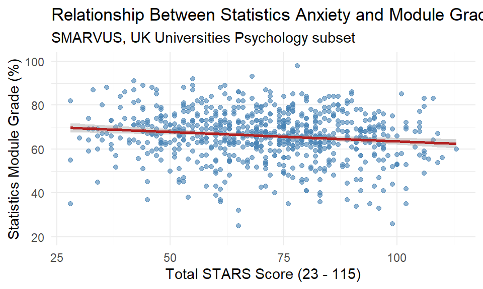

```r
stars_attainment <- ggplot(smarvus_uk_scored, aes(x = stars_score, y = grade_numeric)) +
  geom_point(alpha = 0.6, color = "steelblue") +
  geom_smooth(method = "lm", color = "firebrick", se = TRUE) +
  labs(
    title = "Relationship Between Statistics Anxiety and Module Grades",
    subtitle = "SMARVUS, UK Universities Psychology subset",
    x = "Total STARS Score (23 - 115)",
    y = "Statistics Module Grade (%)"
  ) +
  scale_y_continuous(limits = c(20, 100)) +
  theme_minimal()

stars_attainment
```

This plot suggests there is a weakly negative relationship between statistics anxiety and statistics module grades. The predicted grade at a STARS score of 28 is around 70%, while for a STARS score of 115 it is around 62%. Using Pearson’s correlation coefficient to measure the strength of the relationship, we found that the correlation was -0.14, with $p<0.001$ , and a 95% confidence interval of [-0.21, -0.06]. Taken together, these results indicate a weak but statistically significant negative relationship between statistics anxiety and attainment.

However, due to the nature of the study, we cannot conclude whether this relationship is causal or whether other factors contributed to or explain the observed relationship. We additionally converted the correlation coefficient into our Cohen’s d effect size value, and found an effect size of -0.28. As our variables are continuous, calculating Cohen’s d directly from group means was not appropriate. We considered splitting participants manually into two groups (“high” and “low” anxiety), but decided against this as the splitting would be arbitrary and would result in loss of information.

The scatterplot shows no obvious outliers or curvature, so the relationship between STARS score and grade appears to be approximately linear. Both histograms are also roughly symmetric and unimodal, so neither variable is strongly skewed. We therefore considered Pearson’s correlation more appropriate than Spearman’s. Furthermore, the conversion from a correlation to Cohen’s $d$, $d = \frac{2r}{\sqrt{1-r^2}}$, is defined for Pearson’s $r$, so using Spearman would only give a rough approximation.

### Relationships Between Other Variables

#### Alternate Anxiety Measures

We firstly examined the relationships between different measures of statistics anxiety and mathematics anxiety. This allowed us to investigate whether the phrasing of the questions was influencing the results, as well as how closely related maths and statistics anxiety were. This is particularly important as it may be difficult to distinguish the effects of each type of anxiety on attainment.

The dataset had questions used to measure statistics anxiety (stars_score) and questions used to measure maths anxiety (rmars_score). The researchers created additional measures by adapting the wording of the questions: so the statistics questions were posed again but with the word “statistics” replaced by “maths” (stars_m_score) and vice versa, so the maths questions were posed again but with the word “maths” replaced by “statistics” (rmars_s_score).

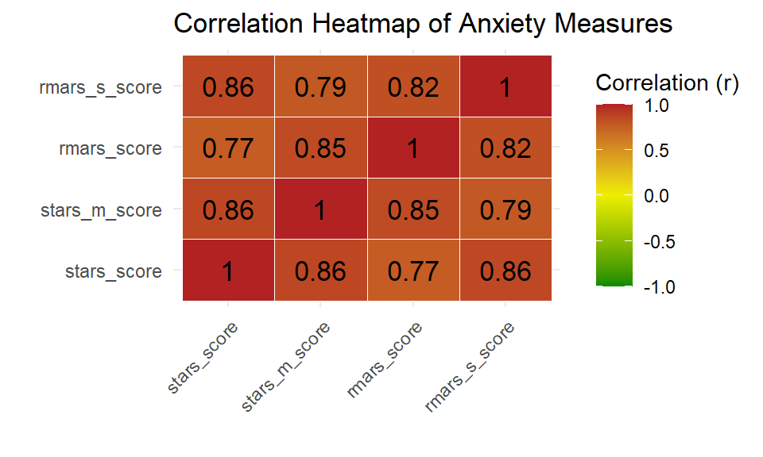

```r
# STARS Score is as calculated previously

# STARS-M Score
stars_m_totals <- smarvus_uk_cleangrades %>%
  subset(select = -c(Q8.1_21)) %>%
  pivot_longer(
    cols = starts_with("Q8.1_"),
    values_to = "STARS_M"
  ) %>%
  summarise(
    .by = unique_id,
    stars_m_score = sum(STARS_M)
  )

# R-MARS Score
rmars_totals <- smarvus_uk_cleangrades %>%
  subset(select = -c(Q8.2_21, Q8.2_22, Q8.2_23, Q8.2_24)) %>%
  pivot_longer(
    cols = starts_with("Q8.2_"),
    values_to = "R_MARS"
  ) %>%
  summarise(
    .by = unique_id,
    rmars_score = sum(R_MARS)
  )

# R-MARS-S Score
rmars_s_totals <- smarvus_uk_cleangrades %>%
  subset(select = -c(Q7.2_20, Q7.2_21, Q7.2_22, Q7.2_23)) %>%
  pivot_longer(
    cols = starts_with("Q7.2_"),
    values_to = "R_MARS_S"
  ) %>%
  summarise(
    .by = unique_id,
    rmars_s_score = sum(R_MARS_S)
  )

# join into a single df
smarvus_all_scores <- smarvus_uk_cleangrades %>%
  left_join(stars_totals, by = "unique_id") %>%
  left_join(stars_m_totals, by = "unique_id") %>%
  left_join(rmars_totals, by = "unique_id") %>%
  left_join(rmars_s_totals, by = "unique_id")

anxiety_corrs <- smarvus_all_scores %>%
  select(stars_score, stars_m_score, rmars_score, rmars_s_score) %>%
  cor(use = "complete.obs")

cor_long <- as.data.frame(as.table(anxiety_corrs))

ggplot(cor_long, aes(Var1, Var2, fill = Freq)) +
  geom_tile(color = "white") +
  scale_fill_gradient2(low = "green4", high = "firebrick", mid = "yellow2",
                       midpoint = 0, limit = c(-1, 1), name = "Correlation (r)") +
  geom_text(aes(label = round(Freq, 2)), color = "black", size = 4.5) +
  theme_minimal() +
  labs(
    title = "Correlation Heatmap of Anxiety Measures",
    x = "",
    y = ""
  ) +
  theme(axis.text.x = element_text(angle = 45, hjust = 1))
```

#### Exploratory Multiple Linear Regression

Our above correlation and effect size describes the relationship between anxiety and attainment in isolation. However, grades may differ between universities, genders, degree years and levels of prior maths education, and if these characteristics are also related to STARS scores, the observed correlation could partly reflect them. We therefore decided to fit a multiple linear regression model to investigate whether the observed negative association between statistics anxiety and attainment persisted after accounting for these other variables. Since we investigated the effect on attainment, statistics module grade was used as the response variable with total STARS score as the main explanatory variable. University, gender, degree year and prior mathematics education were included as additional explanatory variables to account for potential differences in institutional context and student characteristics. The regression also allows the effect to be expressed in units that are easier to interpret (percentage points of grade per point of STARS score) and reveals how much of the variation in grades the predictors explain.

##### Exploratory Data Analysis

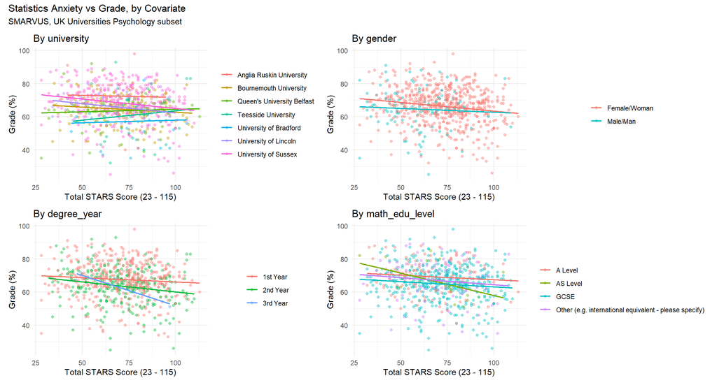

```r
reg_data <- smarvus_uk_scored %>%
  filter(gender %in% c("Female/Woman", "Male/Man")) %>%
  mutate(gender = factor(gender, levels = c("Female/Woman", "Male/Man"))) %>%
  drop_na(grade_numeric, stars_score, university, gender, degree_year, math_edu_level)

covariates <- c("university", "gender", "degree_year", "math_edu_level")

make_plot <- function(var) {

  plot <- ggplot(reg_data, aes(x = stars_score, y = grade_numeric, color = .data[[var]])) +
    geom_point(alpha = 0.4) +
    geom_smooth(method = "lm", se = FALSE, linewidth = 0.8) +
    labs(
      title = paste("By", var),
      x = "Total STARS Score (23 - 115)",
      y = "Grade (%)",
      color = NULL
    ) +
    theme_minimal()

  return(plot)
}

plots <- map(covariates, make_plot)

stars_grid <- wrap_plots(plots, ncol = 2) +
  plot_annotation(
    title = "Statistics Anxiety vs Grade, by Covariate",
    subtitle = "SMARVUS, UK Universities Psychology subset"
  )

stars_grid
```

The university level data is noisy, and some universities have many more observations than others (for example University of Sussex), so it is difficult to make strong conclusions from the scatterplot. However, we observed that there is a difference between grades at the same STARS scores, and the general trend of grade vs STARS score differs between universities.

The grade vs STARS score slope also differed between men and women, with women’s grades decreasing at a faster rate as statistics anxiety levels increase compared to men. This could be explained by difference in approaches to anxiety and assessment between men and women but further investigations would be required to explore this.

Noting that there is more data for first and second year students in comparison to third year students, we observed that second year students’ grades decrease more as statistics anxiety increases, which could possibly be explained by an increase in difficulty between first and second year.

Finally, attainment vs STARS score varies by the highest level of maths education prior to university, with students who took A-Level Maths having higher grades for each STARS score in comparison to students who only took GCSE Maths.

Therefore we have evidence to include these covariates in our multiple regression model. It is also important to check for correlation between covariates, since strongly correlated predictors can inflate the standard errors of coefficient estimates and make them difficult to interpret. The following correlation heatmap uses Cramér’s V score to find the association between the categorical factors.

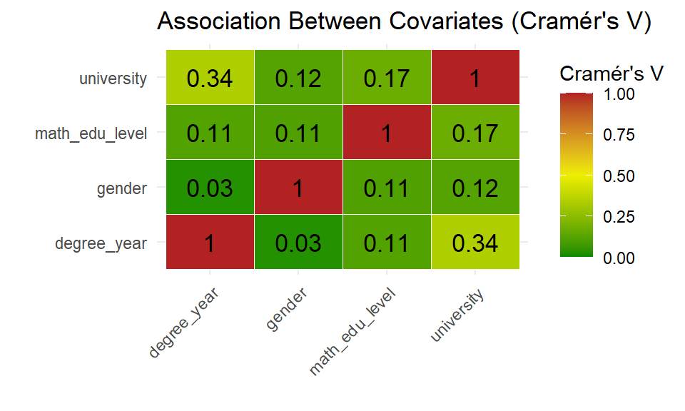

```r
cat_vars <- c("gender", "degree_year", "math_edu_level", "university")

cv_long <- expand_grid(v1 = cat_vars, v2 = cat_vars) %>%
  mutate(cramer_v = map2_dbl(v1, v2, ~ {
    tab <- table(reg_data[[.x]], reg_data[[.y]])
    suppressWarnings(rstatix::cramer_v(tab))
    }))

cv_plot <- ggplot(cv_long, aes(v1, v2, fill = cramer_v)) +
  geom_tile(color = "white") +
  scale_fill_gradient2(low = "green4", high = "firebrick", mid = "yellow2",
                       midpoint = 0.5, limit = c(0, 1), name = "Cramér's V") +
  geom_text(aes(label = round(cramer_v, 2)), color = "black", size = 4.5) +
  theme_minimal() +
  labs(
    title = "Association Between Covariates (Cramér's V)",
    x = "",
    y = ""
  ) +
  theme(axis.text.x = element_text(angle = 45, hjust = 1))

cv_plot
```

From this plot, we saw that the strongest association is between university and degree year, which indicates that the number of students in each degree year wasn’t distributed the same across the universities for our data. However, none of the associations are very large, so there is no evidence of redundancy amongst the covariates, therefore we did not make any adjustment for this when creating the model.

##### Model fitting

Our full model was
$$\text{Grade}_i = \beta_0 + \beta_1\,\text{STARS}_i + \sum_{j=2}^{7}
\gamma_j\,\text{Uni}_{ij} + \delta\,\text{Male}_i + \sum_{k=2}^{3}
\theta_k\,\text{Year}_{ik} + \sum_{m=2}^{4}
\lambda_m\,\text{MathEdu}_{im} + \varepsilon_i, \qquad \varepsilon_i
\sim N(0, \sigma^2),$$
where $\text{Grade}_i$ is the statistics module grade (%) of student $i$, $\text{STARS}_i$ is their total STARS score, and $\text{Male}_i$ is an indicator equal to 1 if the student is male and 0 if female. $\text{Uni}_{ij}$, $\text{Year}_{ik}$ and $\text{MathEdu}_{im}$ are indicator variables for university, degree year and highest level of prior mathematics education respectively, each with one reference category. $\varepsilon_i$ are independent errors with constant variance $\sigma^2$.

We used backward elimination to obtain a more parsimonious model. Starting with the full model, we used partial F-tests to assess each explanatory variable. At each step, the variable with the largest p-value was considered for removal, provided it was not STARS score since it was the main variable of interest.

```r
# Full model
lm_full <- lm(grade_numeric ~ stars_score + factor(university) + factor(gender) + factor(degree_year) + factor(math_edu_level), data = reg_data)

# Partial F-test for backwards elimination
drop1(lm_full, test = "F")
```

|  | Df | Sum of Sq | RSS | AIC | F value | Pr(>F) |
| --- | --- | --- | --- | --- | --- | --- |
|  | NA | NA | 76053.51 | 3328.101 | NA | NA |
| stars_score | 1 | 1229.8176 | 77283.32 | 3337.410 | 11.173764 | 8.743444e-04 |
| factor(university) | 6 | 4950.0980 | 81003.60 | 3360.556 | 7.495858 | 8.487039e-08 |
| factor(gender) | 1 | 660.2357 | 76713.74 | 3332.195 | 5.998709 | 1.456363e-02 |
| factor(degree_year) | 2 | 2329.4379 | 78382.94 | 3345.371 | 10.582297 | 2.972655e-05 |
| factor(math_edu_level) | 3 | 733.0287 | 76786.53 | 3328.864 | 2.220028 | 8.456294e-02 |

```r
lm2 <- lm(grade_numeric ~ stars_score + factor(university) + factor(gender) + factor(degree_year), data = reg_data)

drop1(lm2, test = "F")
```

|  | Df | Sum of Sq | RSS | AIC | F value | Pr(>F) |
| --- | --- | --- | --- | --- | --- | --- |
|  | NA | NA | 76786.53 | 3328.864 | NA | NA |
| stars_score | 1 | 1441.6747 | 78228.21 | 3339.977 | 13.029918 | 3.286127e-04 |
| factor(university) | 6 | 5425.6421 | 82212.18 | 3364.997 | 8.172864 | 1.474904e-08 |
| factor(gender) | 1 | 662.9164 | 77449.45 | 3332.924 | 5.991467 | 1.462194e-02 |
| factor(degree_year) | 2 | 2565.5906 | 79352.13 | 3348.034 | 11.593959 | 1.114545e-05 |

Since none of the terms have a p-value greater than 0.05, we remove no further terms from this model.

Our final model was therefore
$$\text{Grade}_i = \beta_0 + \beta_1\,\text{STARS}_i + \sum_{j=2}^{7}
\gamma_j\,\text{Uni}_{ij} + \delta\,\text{Male}_i + \sum_{k=2}^{3}
\theta_k\,\text{Year}_{ik} + \varepsilon_i, \qquad \varepsilon_i \sim
N(0, \sigma^2).$$

```r
summary(lm2)
```

```
##
## Call:
## lm(formula = grade_numeric ~ stars_score + factor(university) +
##     factor(gender) + factor(degree_year), data = reg_data)
##
## Residuals:
##     Min      1Q  Median      3Q     Max
## -38.684  -5.373   0.857   6.443  30.942
##
## Coefficients:
##                                               Estimate Std. Error t value
## (Intercept)                                   78.88255    3.21198  24.559
## stars_score                                   -0.08423    0.02334  -3.610
## factor(university)Bournemouth University      -6.17119    2.86464  -2.154
## factor(university)Queen's University Belfast  -8.27629    2.93959  -2.815
## factor(university)Teesside University         -6.74783    3.43317  -1.965
## factor(university)University of Bradford     -13.24812    3.43212  -3.860
## factor(university)University of Lincoln       -3.04451    3.13420  -0.971
## factor(university)University of Sussex        -2.52799    2.80153  -0.902
## factor(gender)Male/Man                        -2.84646    1.16289  -2.448
## factor(degree_year)2nd Year                   -4.34870    0.90650  -4.797
## factor(degree_year)3rd Year                   -5.25926    5.40059  -0.974
##                                              Pr(>|t|)
## (Intercept)                                   < 2e-16 ***
## stars_score                                  0.000329 ***
## factor(university)Bournemouth University     0.031563 *
## factor(university)Queen's University Belfast 0.005009 **
## factor(university)Teesside University        0.049757 *
## factor(university)University of Bradford     0.000124 ***
## factor(university)University of Lincoln      0.331696
## factor(university)University of Sussex       0.367177
## factor(gender)Male/Man                       0.014622 *
## factor(degree_year)2nd Year                  1.97e-06 ***
## factor(degree_year)3rd Year                  0.330481
## ---
## Signif. codes:  0 '***' 0.001 '**' 0.01 '*' 0.05 '.' 0.1 ' ' 1
##
## Residual standard error: 10.52 on 694 degrees of freedom
## Multiple R-squared:  0.1192, Adjusted R-squared:  0.1065
## F-statistic:  9.39 on 10 and 694 DF,  p-value: 1.028e-14
```

```r
# 95% CI for STARS score
confint(lm2)["stars_score", ]
```

```
##       2.5 %      97.5 %
## -0.13005133 -0.03841763
```

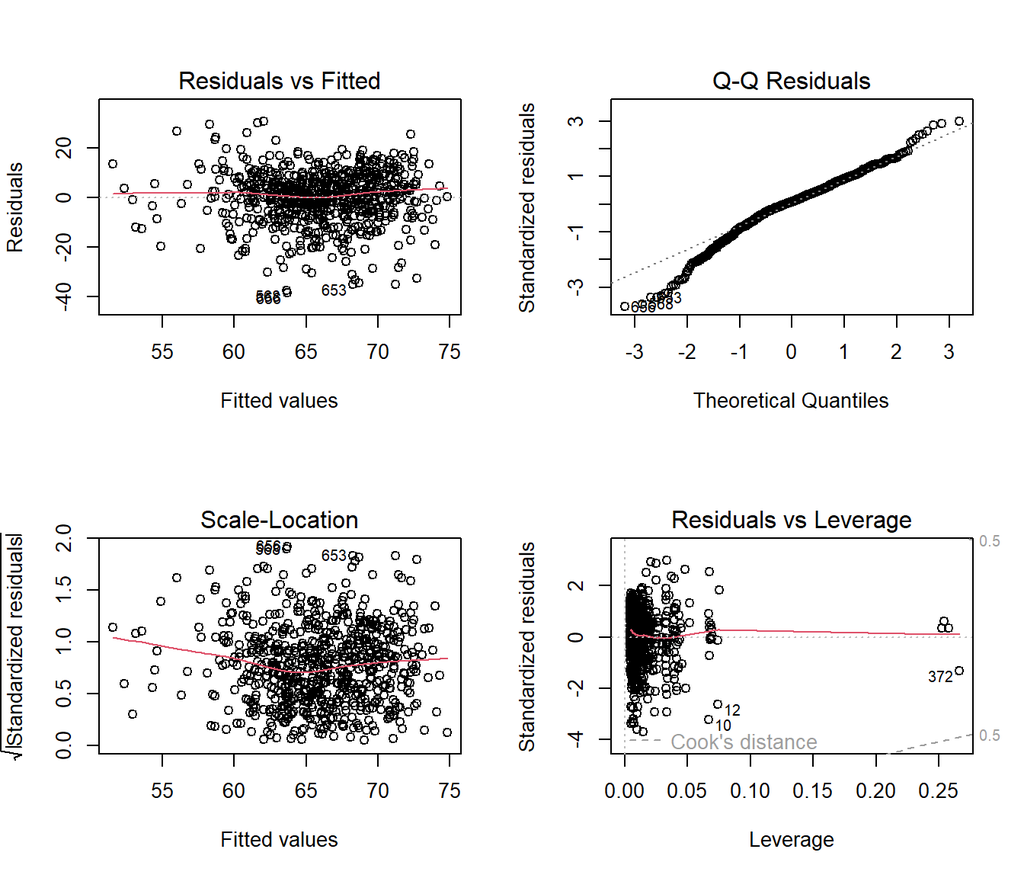

```r
par(mfrow = c(2,2))
plot(lm2)
```

We also examined residual diagnostic plots to assess the assumptions of the linear regression model. These indicated slight heteroscedasticity and deviations from normality in the tails of the Q-Q plot. However, these departures were not considered sufficiently severe to invalidate the analysis.

This suggests that the negative association between statistics anxiety and attainment observed in the Pearson correlation analysis persists after adjusting for other student characteristics. However, this still cannot establish causation.

## References

Terry, J., L. Tip, C. Lea, Z. M. Flack, and M. Brolly. 2023. “Data from an International Multi-Centre Study of Statistics and Mathematics Anxieties and Related Variables in University Students (the SMARVUS Dataset).” *Journal of Open Psychology Data*.